# Effects of Loan Variables on Loan Amount and Borrower Rate

## by Oreva Egwebe

## Investigation Overview

In this investigation, I wanted to look at the variables that affect loan amount and borrower rate. The main focus was on loan original amount, borrower rate, prosper rating, credit grade, monthly income, employment status and home owners.

## Dataset Overview

This dataset from Prosper loan contains 81 columns and 113,937 observations with variables such as loan amount, borrower rate (or interest rate), current loan status, borrower income, and many others which will be further investigated to find out which factors affect the outcome of a loan and interest rate. I created a smaller dataframe with about 20 columns of interest to help focus my investigation.

## Distribution of Loan Amount

Loan amount in the dataset take on a very large range of values, from a minimum of 1000 to a maximum of 35000. The distribution shows a very high frequency for 4000, 10000 and 15000 (in $) loan amounts.

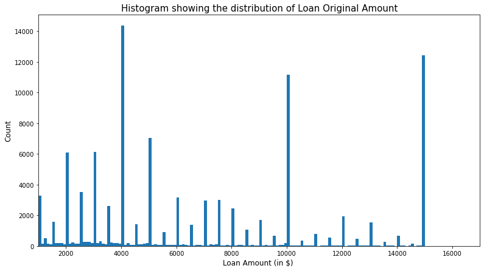

## Loan Original Amount vs Employment Status

The chart shows $4000 as a popular loan amount across the different employment categories. This corresponds with the previous histogram of loan original amount plotted.

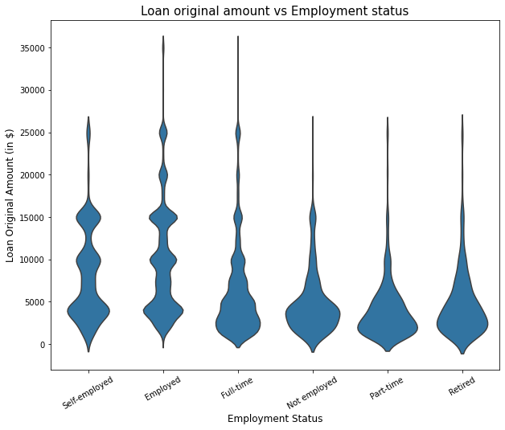

## Credit Grade and Prosper Rating by Borrower Rate

We can see the similarities of how credit grade and prosper rating affect borrower rate despite the fact that credit grade was implemented before 2009 while prosper rating was implemented after 2009. Within each level of rating, we observe an increase in borrower rate based on the ratings (AA is the highest, HR is the Lowest).

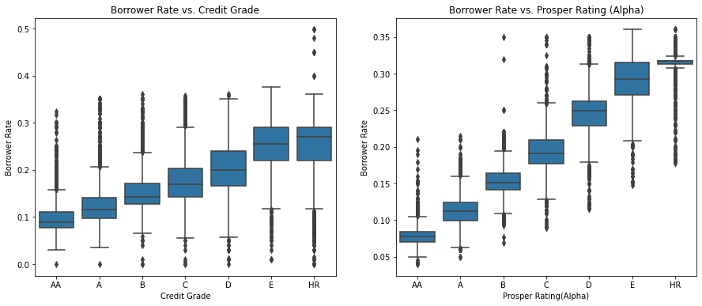

## Correlation of the Numeric Variables

The correlation coefficient of borrower rate and loan original amount is -0.33 and shows a negative moderate correlation between loan original amount and borrower rate which means that borrower rate does not increase as loan original amount increases. There is a weak correlation between stated monthly income and borrower rate, also with loan original amount.

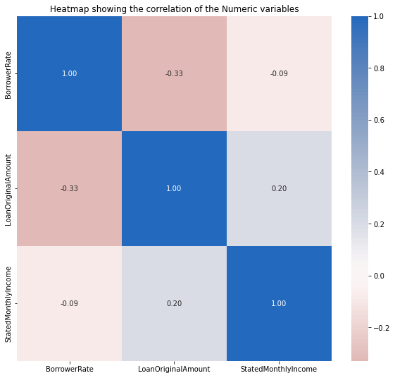

## Home Owners, Borrower Rate by Year

We can see the trend of home owners and their borrower rates across the years which show borrowers that are not home owners tend to have a higher interest rate compared to home owners.

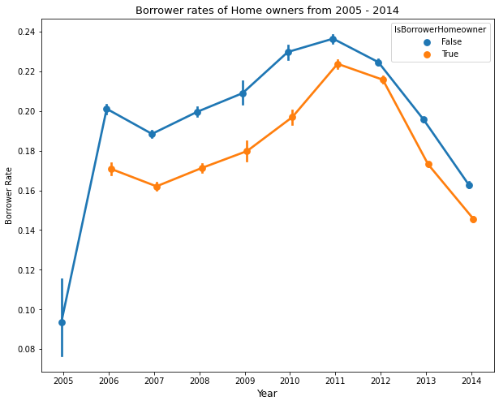

## Employment Status, Home Owners by Loan Amount and Borrower Rate

We can see clearly from the point plot charts that being a home owner helps you access a higher loan amount for all employment status categories. Borrowers not employed have a higher interest rate despite the fact if they are home owners or not.

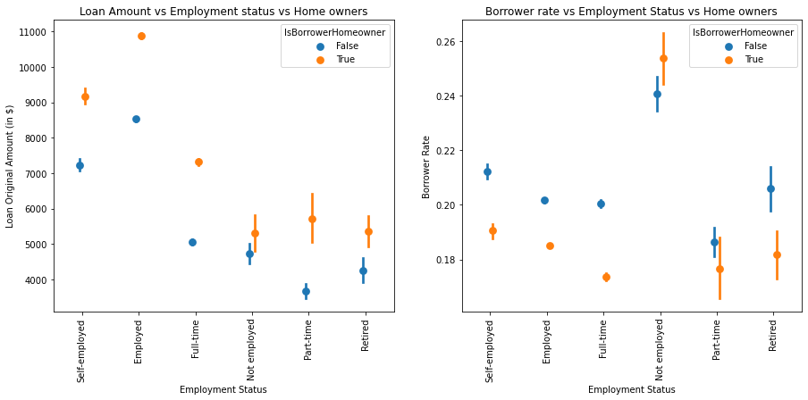